# Inleiding tot visualiseren van netwerkdata in R

# 5. Visualisaties met behulp van het `ggraph`-package

In dit deel introduceren we het `ggraph`-package, eveneens een handige tool voor het visualiseren van netwerken binnen het `tidyverse`-ecosysteem. `ggraph` biedt uitgebreide mogelijkheden om complexe netwerken op een flexibele en esthetisch verantwoorde wijze te presenteren. Door de nauwe integratie met `ggplot2` kunnen gebruikers laag voor laag grafische elementen toevoegen en zo gedetailleerde en aanpasbare netwerkvisualisaties realiseren. Deze aanpak stelt onderzoekers in staat om zowel de structuur als de eigenschappen van netwerken inzichtelijk te maken en te communiceren.

Laat ons starten met een eenvoudige plot:

```
## Using "stress" as default layout
```

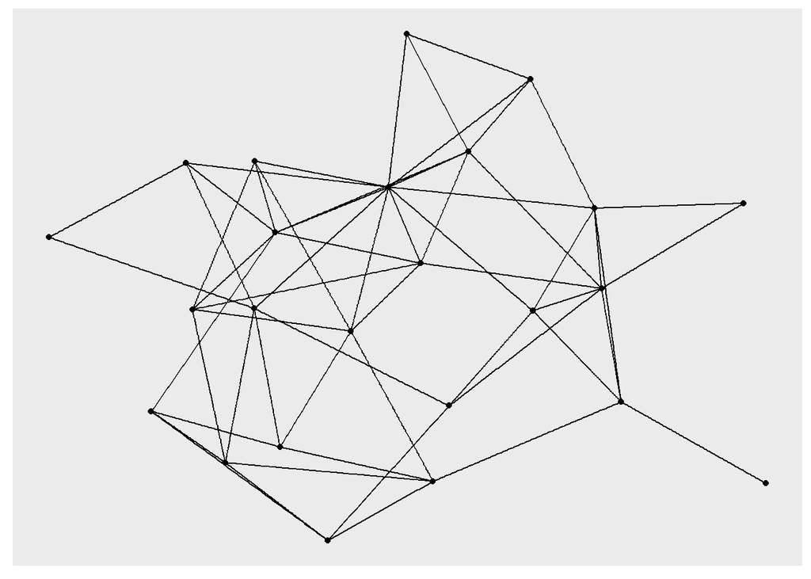

```r
library(ggraph)
library(igraph)
ggraph(class_matrix_net) +
  geom_edge_link() +   # add edges to the plot
  geom_node_point()    # add nodes to the plot
```

In `ggraph` kunnen we gebruikmaken van verschillende functies om de randen van het netwerk te visualiseren:

- `geom_edge_link()` voor rechte verbindingen,
- `geom_edge_arc()` voor gebogen lijnen,
- en `geom_edge_fan()` om overlappende multiplex-edges overzichtelijk uit te spreiden.

Net als bij andere pa ckageskunnen visuele eigenschappen van het netwerk worden ingesteld via belangrijke functiewaarden. Zo kunnen nodes worden aangepast qua kleur, vulkleur, vorm, grootte en randdikte. Edges kunnen worden ingesteld op kleur, dikte en lijntype. Daarnaast regelt de parameter `alpha` de transparantie van deze elementen.

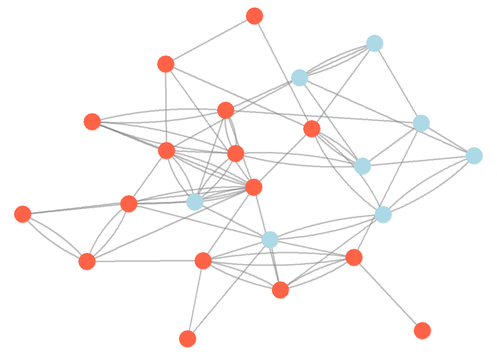

```r
colrs <- c("Male" = "lightblue", "Female" = "tomato")
gender_vals <- V(class_matrix_net)$gender
V(class_matrix_net)$color <- colrs[as.character(gender_vals)]

ggraph(class_matrix_net, layout="gem") +
  geom_edge_fan(color="gray50", width=0.8, alpha=0.5) +
  geom_node_point(color=V(class_matrix_net)$color, size=8) +
  theme_void()
```

Net zoals in `ggplot2` kunnen we verschillende thema’s aan een plot toevoegen. Voor een strakkere en overzichtelijke uitstraling kun je gebruikmaken van een minimalistisch of leeg thema, zoals `theme_minimal()` of `theme_void()`.

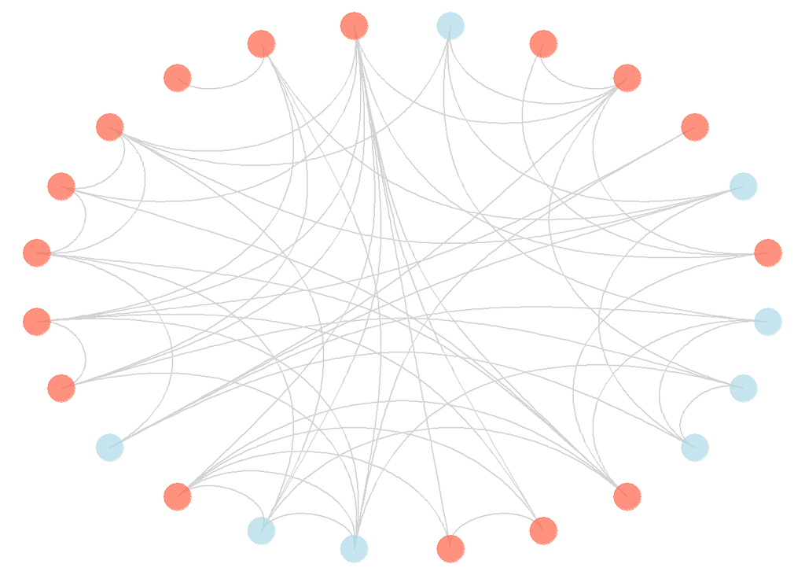

```r
ggraph(class_matrix_net, layout = 'linear', circular = TRUE) +
    geom_edge_arc(color = "lightgray", width=0.4) +
    geom_node_point(color=V(class_matrix_net)$color, size=8, alpha = 0.7) +
    theme_void()
```

Het `ggraph`-package gebruikt eveneens de traditionele `ggplot2`-manier van het mappen van aesthetics: dat wil zeggen het specificeren welke elementen uit de data corresponderen met verschillende visuele eigenschappen van de grafiek.

Dit gebeurt met de functie `aes()`, waarmee visuele parameters worden gekoppeld aan attribuutnamen uit de data.

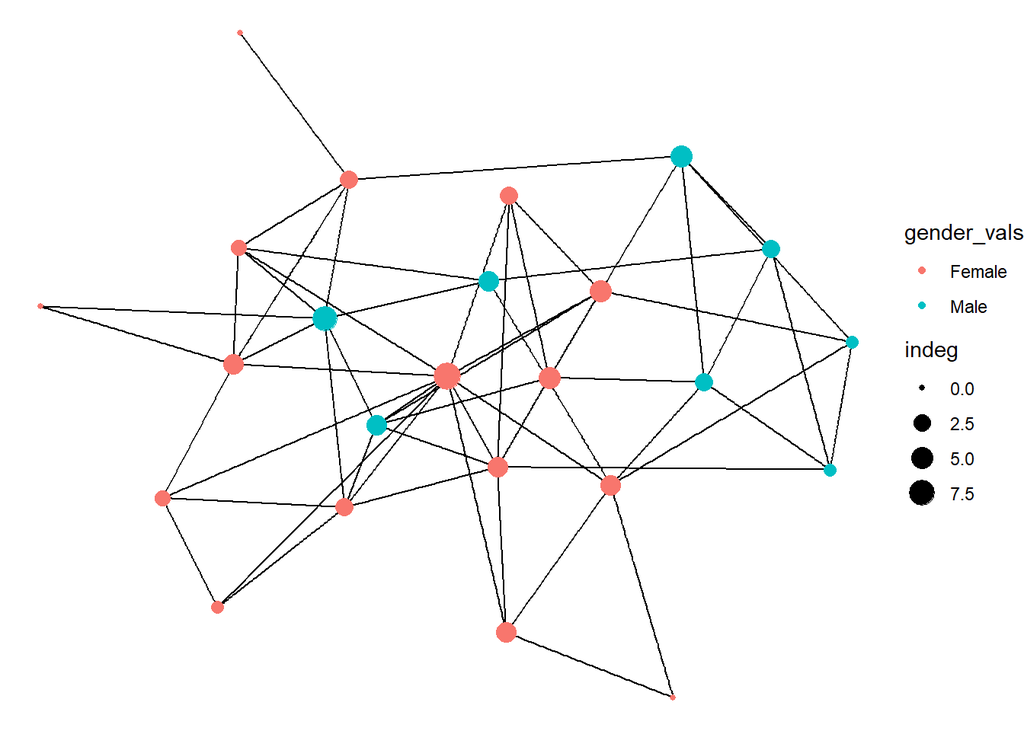

```r
ggraph(class_matrix_net, layout = "gem") +
  geom_edge_link(aes(color = class_matrix_net$gender)) +
  geom_node_point(aes(size = indeg, color = gender_vals)) +
  theme_void()
```

**Einde van deze notebook**